# w3-2-maxlikelihood

Knut Behrends

January 2, 2016

## MLE Exercises #1 (1 point possible)

In this assessment we are going to try to answer the question: is there a section of the human cytomegalovirus genome in which the rate of palindromes is higher than expected?

Make sure you have the latest version of the dagdata library:

```r
library(devtools)
#install_github("genomicsclass/dagdata")
```

and then load the palindrome data from the Human cytomegalovirus genome:

```r
library(dagdata)
# human cytomegalovirus
data(hcmv) # loads 'locations'
```

These are the locations of palindromes on the genome of this virus:

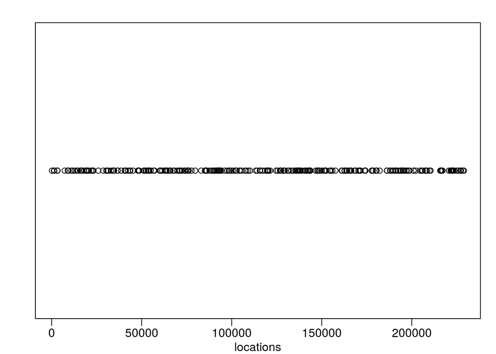

```r
library(rafalib)
mypar()
#bigpar()
plot(locations,rep(1,length(locations)),ylab="",yaxt="n")
```

These palindromes are quite rare, p is very small. If we break the genome into bins of 4000 basepairs, then we have `N * p` not so small, and we might be able to use Poisson to model the number of palindromes in each bin:

```r
breaks=seq(0,4000*round(max(locations)/4000),4000)
tmp=cut(locations,breaks)
(counts=as.numeric(table(tmp)))
```

```
##  [1]  7  1  5  3  8  6  1  4  5  3  6  2  5  8  2  9  6  4  9  4  1  7  7
## [24] 14  4  4  4  3  5  5  3  6  5  3  9  9  4  5  6  1  7  6  7  5  3  4
## [47]  4  8 11  5  3  6  3  1  4  8  6
```

So if our model is correct counts should follow a Poisson distribution. The distribution seems about right:

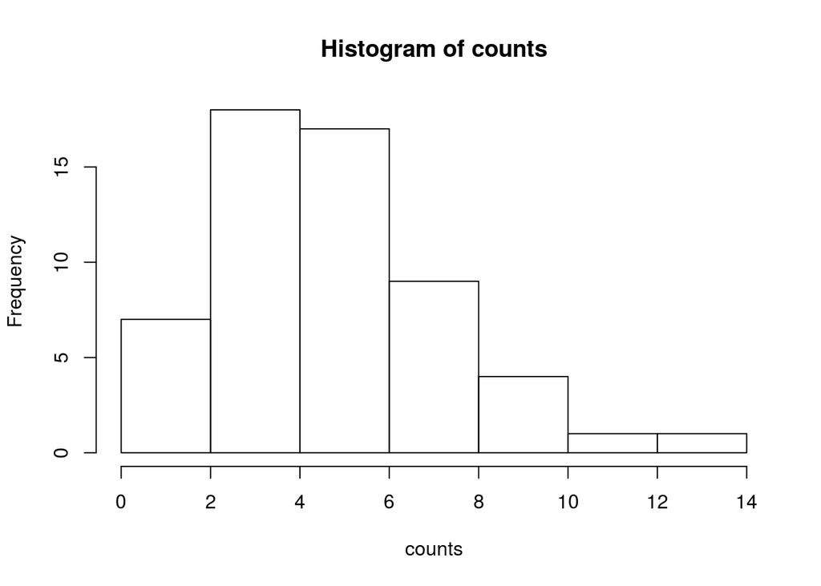

```r
hist(counts)
```

Let X1,…,Xn be the random variables representing counts then

`Pr(Xi=k) = λk / k! * exp(−λ)`

So to fully describe this distribution we need `λ`. For this we will use MLE.

To compute the Maximum Likelihood Estimate (MLE), we ask what is the probability of observing our data (which we denote with small caps) for a given λ:

`L(λ) = Pr(X1=x1 and X2=x2 and …Xn=xn;λ)`

We assume that the X are independent, thus the probabilities multiply:

`L(λ) = Pr(X1=x1) × Pr(X2=x2) × ⋯ × Pr(Xn=xn)`

Now we can write it in R. For example for `λ=4` we have:

```r
probs <- dpois(counts,4)
likelihood <- prod(probs)
likelihood
```

```
## [1] 1.178e-62
```

Run the code above to note that this is a tiny number. It is usually more convenient to compute log-likelihoods

```r
logprobs <- dpois(counts,4,log=TRUE)
loglikelihood <- sum(logprobs)
loglikelihood
```

```
## [1] -142.6
```

Now write a function that takes `λ` and the vector of counts as input, and returns the log-likelihood. Compute this log-likelihood for `lambdas = seq(0,15,len=300)` and make a plot.

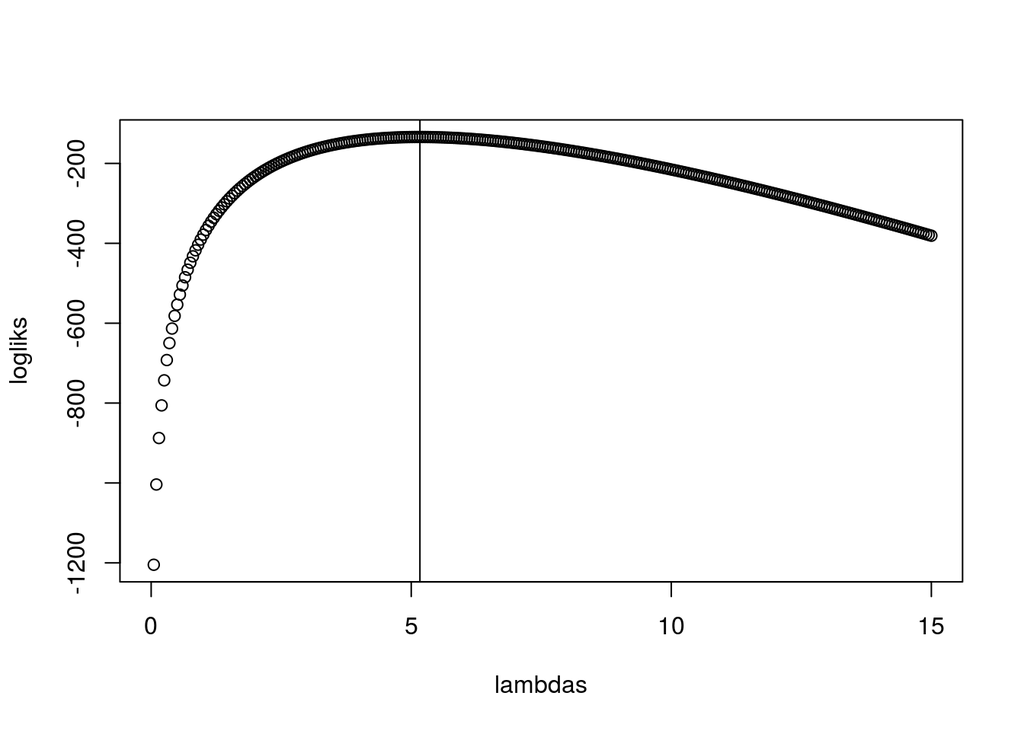

```r
myloglik <- function(lambda, counts){
        logprobs <- sum(dpois(counts,lambda,log=TRUE))
        loglikelihood <- sum(logprobs)
        return(loglikelihood)

}
lambdas = seq(0,15,len=300)
logliks <- sapply(lambdas, myloglik, counts)
plot(lambdas, logliks)
mle=lambdas[which.max(logliks)]
abline(v=mle)
```

What value of lambdas maximizes the log-likelihood?

```r
mle
```

```
## [1] 5.167
```

### MLE Exercises #2 (1 point possible)

The point of collecting this dataset was to try to determine if there is a region of the genome that has higher palindrome rate than expected. We can create a plot and see the counts per location:

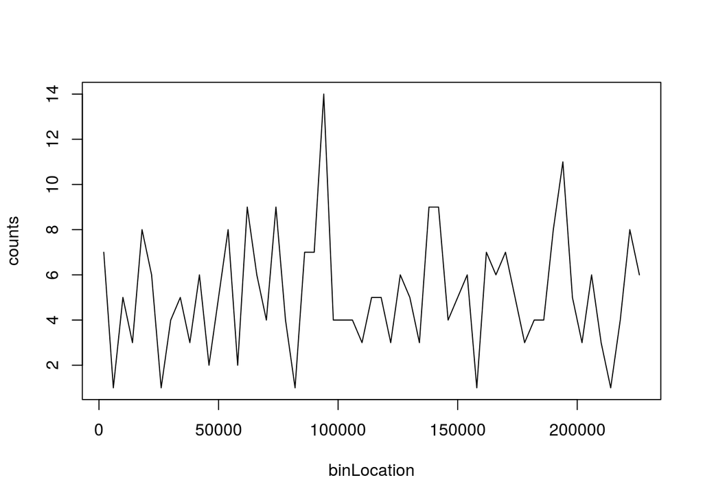

```r
breaks=seq(0,4000*round(max(locations)/4000),4000)
tmp=cut(locations,breaks)
counts=as.numeric(table(tmp))
binLocation=(breaks[-1]+breaks[-length(breaks)])/2
plot(binLocation,counts,type="l",xlab=)
```

What is the center of the bin with the highest count?

```r
binLocation[which.max(counts)]
```

```
## [1] 94000
```

### MLE Exercises #4 (1 point possible)

Now that we have identified the location with the largest palindrome count, we want to know if by chance we could see a value this big.

If X is a Poisson random variable with rate

```r
lambda = mean(counts[ - which.max(counts) ])
```

What is the probability of seeing a count of 14 or more?

```r
(p14 <- 1-sum(dpois(0:13,lambda)))
```

```
## [1] 0.000698
```

```r
# rafa's solution:   pval = 1 - ppois(13,lambda)
```

### MLE Exercises #5 (1 point possible)

From the question above, we obtain a p-value smaller than 0.001 for a count of 14. Why is it problematic to report this p-value as strong evidence of a location that is different?

- Poisson in only an approximation.
- We selected the highest region out of 57 and need to adjust for multiple testing.
- λ is an estimate, a random variable, and we didn’t take into account its variability.
- We don’t know the effect size.

### MLE Exercises #6 (1 point possible)

Use the Bonferroni correction to determine the p-value cut-off that guarantees a FWER of 0.05. What is this p-value cutoff?

```r
(cutoff = 0.05/length(counts))
```

```
## [1] 0.0008772
```

```r
p14  < cutoff
```

```
## [1] TRUE
```

Note that our observed p-value satisfy the Bonferroni correction.

### MLE Exercises #7 (1 point possible)

Create a qq-plot to see if our Poisson model is a good fit:

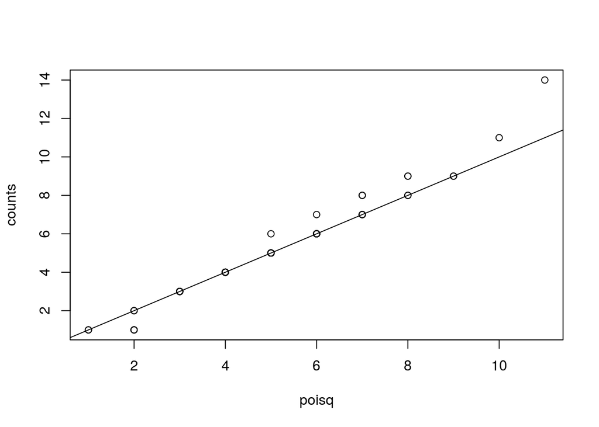

```r
ps <- (seq(along=counts) - 0.5)/length(counts)
lambda <- mean( counts[ -which.max(counts)])
poisq <- qpois(ps,lambda)
qqplot(poisq,counts)
abline(0,1)
```

How would you characterize this qq-plot?

- Poisson is a terrible approximation.
- Poisson is a very good approximation except for one point that we actually think is associated with a region of interest.
- There are too many 1s in the data.
- ~~A normal distribution provides a better approximation. ~~